# LaLiga_up_to_10

```python
import os
import pandas as pd
import numpy as np
import sqlite3
import matplotlib.pyplot as plot
from pathlib import Path
```

```python
dir = Path.cwd()
laliga_path = dir / "laliga.sqlite"
if not laliga_path.exists():
    print(f"'laliga.sqlite' not found in current directory ({laliga_path}), looking inside parent directory...")
    parent_path = dir.parent / "laliga.sqlite"

    if parent_path.exists() == False:
        raise FileNotFoundError(
            f"Not found 'laliga.sqlite' neither in {laliga_path} nor in {parent_path}"
        )

    laliga_path = parent_path

try:
     conn = sqlite3.connect(laliga_path)
except sqlite3.OperationalError as e:
    print(f"Could not connect to data base 'laliga.sqlite'.")
```

```
'laliga.sqlite' not found in current directory (/mnt/c/Users/laura/Desktop/master/RI/python/la-quiniela/notebooks/laliga.sqlite), looking inside parent directory...
```

```python
df = pd.read_sql("SELECT * FROM Matches;", conn)
df
```

|  | season | division | matchday | date | time | home_team | away_team | score |
| --- | --- | --- | --- | --- | --- | --- | --- | --- |
| 0 | 1928-1929 | 1 | 1 | 2/10/29 | None | Arenas Club | Athletic Madrid | 2:3 |
| 1 | 1928-1929 | 1 | 1 | 2/10/29 | None | Espanyol | Real Unión | 3:2 |
| 2 | 1928-1929 | 1 | 1 | 2/10/29 | None | Real Madrid | Catalunya | 5:0 |
| 3 | 1928-1929 | 1 | 1 | 2/10/29 | None | Donostia | Athletic | 1:1 |
| 4 | 1928-1929 | 1 | 1 | 2/12/29 | None | Racing | Barcelona | 0:2 |
| ... | ... | ... | ... | ... | ... | ... | ... | ... |
| 48775 | 2021-2022 | 2 | 42 | 5/29/22 | None | Real Oviedo | UD Ibiza | None |
| 48776 | 2021-2022 | 2 | 42 | 5/29/22 | None | Real Sociedad B | Real Zaragoza | None |
| 48777 | 2021-2022 | 2 | 42 | 5/29/22 | None | Sporting Gijón | UD Las Palmas | None |
| 48778 | 2021-2022 | 2 | 42 | 5/29/22 | None | CD Tenerife | FC Cartagena | None |
| 48779 | 2021-2022 | 2 | 42 | 5/29/22 | None | Real Valladolid | SD Huesca | None |

48780 rows × 8 columns

# Exercise 1

To be able to make a pie chart with the percentages of the home team wins, visitor team wins and ties, we need to extract the data from our df.

```python
matches = df.copy()
```

```python
valid_matches = matches[matches['score'].notna() & matches['score'].str.contains(':')].copy()
```

```python
valid_matches[['home_goals', 'away_goals']] = (valid_matches['score'].str.split(':', expand=True).astype(int))
valid_matches
```

|  | season | division | matchday | date | time | home_team | away_team | score | home_goals | away_goals |
| --- | --- | --- | --- | --- | --- | --- | --- | --- | --- | --- |
| 0 | 1928-1929 | 1 | 1 | 2/10/29 | None | Arenas Club | Athletic Madrid | 2:3 | 2 | 3 |
| 1 | 1928-1929 | 1 | 1 | 2/10/29 | None | Espanyol | Real Unión | 3:2 | 3 | 2 |
| 2 | 1928-1929 | 1 | 1 | 2/10/29 | None | Real Madrid | Catalunya | 5:0 | 5 | 0 |
| 3 | 1928-1929 | 1 | 1 | 2/10/29 | None | Donostia | Athletic | 1:1 | 1 | 1 |
| 4 | 1928-1929 | 1 | 1 | 2/12/29 | None | Racing | Barcelona | 0:2 | 0 | 2 |
| ... | ... | ... | ... | ... | ... | ... | ... | ... | ... | ... |
| 48345 | 2021-2022 | 2 | 3 | 8/28/21 | 10:00 PM | Ponferradina | Girona | 2:1 | 2 | 1 |
| 48346 | 2021-2022 | 2 | 3 | 8/29/21 | 5:00 PM | SD Amorebieta | UD Almería | 2:1 | 2 | 1 |
| 48347 | 2021-2022 | 2 | 3 | 8/29/21 | 7:30 PM | CD Lugo | Real Valladolid | 0:2 | 0 | 2 |
| 48348 | 2021-2022 | 2 | 3 | 8/29/21 | 7:30 PM | Real Sociedad B | CF Fuenlabrada | 0:0 | 0 | 0 |
| 48349 | 2021-2022 | 2 | 3 | 8/29/21 | 10:00 PM | Burgos CF | SD Eibar | 0:1 | 0 | 1 |

48000 rows × 10 columns

```python
def get_result(row):
    if row['home_goals'] > row['away_goals']:
        return '1'
    elif row['home_goals'] < row['away_goals']:
        return '2'
    else:
        return 'X'
```

```python
valid_matches['result'] = valid_matches.apply(get_result, axis=1)
valid_matches
```

|  | season | division | matchday | date | time | home_team | away_team | score | home_goals | away_goals | result |
| --- | --- | --- | --- | --- | --- | --- | --- | --- | --- | --- | --- |
| 0 | 1928-1929 | 1 | 1 | 2/10/29 | None | Arenas Club | Athletic Madrid | 2:3 | 2 | 3 | 2 |
| 1 | 1928-1929 | 1 | 1 | 2/10/29 | None | Espanyol | Real Unión | 3:2 | 3 | 2 | 1 |
| 2 | 1928-1929 | 1 | 1 | 2/10/29 | None | Real Madrid | Catalunya | 5:0 | 5 | 0 | 1 |
| 3 | 1928-1929 | 1 | 1 | 2/10/29 | None | Donostia | Athletic | 1:1 | 1 | 1 | X |
| 4 | 1928-1929 | 1 | 1 | 2/12/29 | None | Racing | Barcelona | 0:2 | 0 | 2 | 2 |
| ... | ... | ... | ... | ... | ... | ... | ... | ... | ... | ... | ... |
| 48345 | 2021-2022 | 2 | 3 | 8/28/21 | 10:00 PM | Ponferradina | Girona | 2:1 | 2 | 1 | 1 |
| 48346 | 2021-2022 | 2 | 3 | 8/29/21 | 5:00 PM | SD Amorebieta | UD Almería | 2:1 | 2 | 1 | 1 |
| 48347 | 2021-2022 | 2 | 3 | 8/29/21 | 7:30 PM | CD Lugo | Real Valladolid | 0:2 | 0 | 2 | 2 |
| 48348 | 2021-2022 | 2 | 3 | 8/29/21 | 7:30 PM | Real Sociedad B | CF Fuenlabrada | 0:0 | 0 | 0 | X |
| 48349 | 2021-2022 | 2 | 3 | 8/29/21 | 10:00 PM | Burgos CF | SD Eibar | 0:1 | 0 | 1 | 2 |

48000 rows × 11 columns

```python
result_counts = valid_matches['result'].value_counts()
result_counts
```

```
result
1    25321
X    12280
2    10399
Name: count, dtype: int64
```

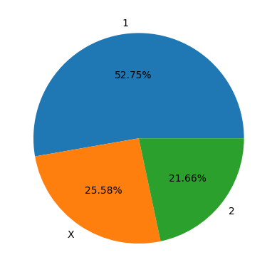

```python
result_counts.plot(kind="pie", autopct = '%1.2f%%', legend = False, ylabel='')
```

We can see clearly that most matches are won by the local team. We could say that the local team has advantatge over the visitor.

# Exercise 2

First, we need to sort the data to get the total goals for each team.

```python
first_division = valid_matches[valid_matches['division'] == 1].copy()
```

```python
division1 = first_division.copy()
```

```python
home_goals_scored = division1.groupby('home_team')['home_goals'].sum()
```

```python
away_goals_scored = division1.groupby('away_team')['away_goals'].sum()
```

```python
total_goals_scored = home_goals_scored.add(away_goals_scored, fill_value=0)
```

```python
total_goals_scored.sort_values(ascending=False).head()
```

```
home_team
Barcelona          6267
Real Madrid        6249
Athletic           4802
Valencia           4615
Atlético Madrid    4184
dtype: int64
```

Secondly, we will compute the total goals conceded for each team.

```python
home_goals_conceded = division1.groupby('home_team')['away_goals'].sum()
```

```python
away_goals_conceded = division1.groupby('away_team')['home_goals'].sum()
```

```python
total_goals_conceded = home_goals_conceded.add(away_goals_conceded, fill_value=0)
```

```python
team_goals = pd.DataFrame({'Goals Scored': total_goals_scored, 'Goals Conceded': total_goals_conceded})
team_goals
```

| home_team | Goals Scored | Goals Conceded |
| --- | --- | --- |
| AD Almería | 72 | 116 |
| Alavés | 608 | 852 |
| Albacete | 320 | 410 |
| Arenas Club | 227 | 308 |
| Ath. Aviación | 113 | 65 |
| ... | ... | ... |
| UD Salamanca | 425 | 581 |
| UE Lleida | 29 | 48 |
| Valencia | 4615 | 3649 |
| Villarreal | 1123 | 986 |
| Xerez CD | 38 | 66 |

68 rows × 2 columns

```python
top10_scored = team_goals.sort_values(by='Goals Scored', ascending=False).head(10)
```

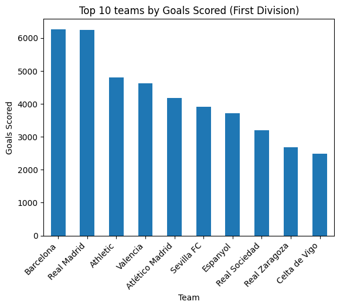

```python
top10_scored['Goals Scored'].plot(kind='bar')
plot.title('Top 10 teams by Goals Scored (First Division)')
plot.ylabel('Goals Scored')
plot.xlabel('Team')
plot.xticks(rotation=45, ha='right')
plot.show()
```

```python
top10_conceded = team_goals.sort_values(by='Goals Conceded', ascending=False).head(10)
```

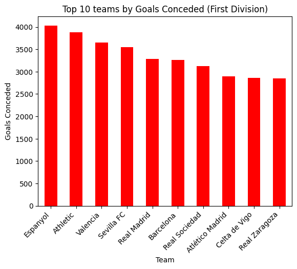

```python
top10_conceded['Goals Conceded'].plot(kind='bar', color='red')
plot.title('Top 10 teams by Goals Conceded (First Division)')
plot.ylabel('Goals Conceded')
plot.xlabel('Team')
plot.xticks(rotation=45, ha='right')
plot.show()
```

Now, we will compute the matches with the biggest goal difference.

```python
first_division['goal_difference'] = (first_division['home_goals'] - first_division['away_goals']).abs()
```

```python
biggest_wins = first_division.sort_values(by='goal_difference', ascending=False).head(10)
biggest_wins
```

|  | season | division | matchday | date | time | home_team | away_team | score | home_goals | away_goals | result | goal_difference |
| --- | --- | --- | --- | --- | --- | --- | --- | --- | --- | --- | --- | --- |
| 225 | 1930-1931 | 1 | 10 | 2/8/31 | None | Athletic | Barcelona | 12:1 | 12 | 1 | 1 | 11 |
| 1071 | 1941-1942 | 1 | 1 | 9/28/41 | None | Sevilla FC | Real Oviedo | 10:0 | 10 | 0 | 1 | 10 |
| 936 | 1940-1941 | 1 | 1 | 9/29/40 | None | Sevilla FC | Barcelona | 11:1 | 11 | 1 | 1 | 10 |
| 1168 | 1941-1942 | 1 | 15 | 1/11/42 | None | Athletic | Celta de Vigo | 10:0 | 10 | 0 | 1 | 10 |
| 2787 | 1950-1951 | 1 | 11 | 11/19/50 | None | Athletic | Lérida | 10:0 | 10 | 0 | 1 | 10 |
| 6 | 1928-1929 | 1 | 2 | 2/17/29 | None | Athletic | Espanyol | 9:0 | 9 | 0 | 1 | 9 |
| 2537 | 1949-1950 | 1 | 2 | 9/11/49 | None | Barcelona | Gimnàstic | 10:1 | 10 | 1 | 1 | 9 |
| 408 | 1932-1933 | 1 | 10 | 1/29/33 | None | Racing | Alavés | 9:0 | 9 | 0 | 1 | 9 |
| 2771 | 1950-1951 | 1 | 9 | 11/5/50 | None | Dep. La Coruña | Lérida | 10:1 | 10 | 1 | 1 | 9 |
| 2969 | 1951-1952 | 1 | 3 | 9/23/51 | None | Athletic | Real Zaragoza | 10:1 | 10 | 1 | 1 | 9 |

What we have seen is that the two teams with the biggest number of goals are Barcelona and Real Madrid. The two teams with the largest number of conceded goals are Espanyol and Athletic. Finally, the match with the biggest difference in goals is athelic vs Barcelona in season 1930-1931.

# Exercise 3

```python
df1 = matches.copy()
```

```python
df1['new_date'] = pd.to_datetime(df1['date'], format='%m/%d/%y', errors='coerce')
df1
```

|  | season | division | matchday | date | time | home_team | away_team | score | new_date |
| --- | --- | --- | --- | --- | --- | --- | --- | --- | --- |
| 0 | 1928-1929 | 1 | 1 | 2/10/29 | None | Arenas Club | Athletic Madrid | 2:3 | 2029-02-10 |
| 1 | 1928-1929 | 1 | 1 | 2/10/29 | None | Espanyol | Real Unión | 3:2 | 2029-02-10 |
| 2 | 1928-1929 | 1 | 1 | 2/10/29 | None | Real Madrid | Catalunya | 5:0 | 2029-02-10 |
| 3 | 1928-1929 | 1 | 1 | 2/10/29 | None | Donostia | Athletic | 1:1 | 2029-02-10 |
| 4 | 1928-1929 | 1 | 1 | 2/12/29 | None | Racing | Barcelona | 0:2 | 2029-02-12 |
| ... | ... | ... | ... | ... | ... | ... | ... | ... | ... |
| 48775 | 2021-2022 | 2 | 42 | 5/29/22 | None | Real Oviedo | UD Ibiza | None | 2022-05-29 |
| 48776 | 2021-2022 | 2 | 42 | 5/29/22 | None | Real Sociedad B | Real Zaragoza | None | 2022-05-29 |
| 48777 | 2021-2022 | 2 | 42 | 5/29/22 | None | Sporting Gijón | UD Las Palmas | None | 2022-05-29 |
| 48778 | 2021-2022 | 2 | 42 | 5/29/22 | None | CD Tenerife | FC Cartagena | None | 2022-05-29 |
| 48779 | 2021-2022 | 2 | 42 | 5/29/22 | None | Real Valladolid | SD Huesca | None | 2022-05-29 |

48780 rows × 9 columns

```python
df1['weekday'] = df1['new_date'].dt.day_name()
```

```python
weekday_counts = df1['weekday'].value_counts()
weekday_counts
```

```
weekday
Sunday       25195
Saturday     20073
Wednesday     1389
Friday         850
Monday         621
Thursday       345
Tuesday        307
Name: count, dtype: int64
```

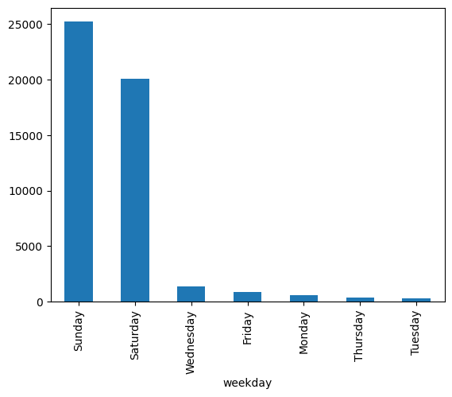

```python
weekday_counts.plot(kind="bar")
```

```python
df1['hour'] = pd.to_datetime(df1['time'], format='%I:%M %p', errors='coerce').dt.hour
```

```python
hours = df1['hour'].dropna()
```

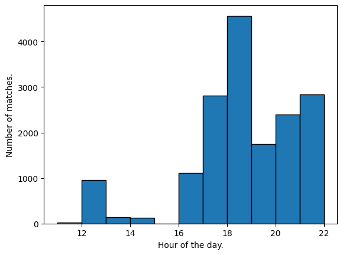

```python
plot.hist(hours, bins=range(11,23), edgecolor='black')
plot.xlabel('Hour of the day.')
plot.ylabel('Number of matches.')
plot.show()
```

As we can see in both charts, matches mostly happen on weekends, especially on Sundays. Regarding the hours, they are more distributed during the afternoon and evening, mostly between 18 and 19.

```python
df1_2000 = df1[df1['season'] == '2000-2001'].copy()
df1_2020 = df1[df1['season'] == '2020-2021'].copy()
df1_2000
```

|  | season | division | matchday | date | time | home_team | away_team | score | new_date | weekday | hour |
| --- | --- | --- | --- | --- | --- | --- | --- | --- | --- | --- | --- |
| 17838 | 2000-2001 | 1 | 1 | 9/9/00 | 8:15 PM | Real Sociedad | Racing | 2:2 | 2000-09-09 | Saturday | 20.0 |
| 17839 | 2000-2001 | 1 | 1 | 9/9/00 | 9:00 PM | Real Zaragoza | Espanyol | 1:2 | 2000-09-09 | Saturday | 21.0 |
| 17840 | 2000-2001 | 1 | 1 | 9/9/00 | 9:00 PM | Barcelona | Málaga CF | 2:1 | 2000-09-09 | Saturday | 21.0 |
| 17841 | 2000-2001 | 1 | 1 | 9/9/00 | 9:00 PM | Dep. La Coruña | Athletic | 2:0 | 2000-09-09 | Saturday | 21.0 |
| 17842 | 2000-2001 | 1 | 1 | 9/9/00 | 9:00 PM | Real Madrid | Valencia | 2:1 | 2000-09-09 | Saturday | 21.0 |
| ... | ... | ... | ... | ... | ... | ... | ... | ... | ... | ... | ... |
| 38693 | 2000-2001 | 2 | 42 | 6/17/01 | None | Albacete | Uni. Las Palmas | 2:3 | 2001-06-17 | Sunday | NaN |
| 38694 | 2000-2001 | 2 | 42 | 6/17/01 | None | Elche CF | SD Compostela | 2:2 | 2001-06-17 | Sunday | NaN |
| 38695 | 2000-2001 | 2 | 42 | 6/17/01 | None | Sporting Gijón | Córdoba CF | 2:2 | 2001-06-17 | Sunday | NaN |
| 38696 | 2000-2001 | 2 | 42 | 6/17/01 | None | Real Jaén CF | Real Betis | 0:2 | 2001-06-17 | Sunday | NaN |
| 38697 | 2000-2001 | 2 | 42 | 6/17/01 | None | Getafe | Atlético Madrid | 0:1 | 2001-06-17 | Sunday | NaN |

842 rows × 11 columns

```python
weekday_counts_2000 = df1_2000['weekday'].value_counts()
weekday_counts_2020 = df1_2020['weekday'].value_counts()
```

```python
weekday_order = ['Monday', 'Tuesday', 'Wednesday', 'Thursday', 'Friday', 'Saturday', 'Sunday']
weekday_counts_2000 = weekday_counts_2000.reindex(weekday_order).fillna(0)
weekday_counts_2020 = weekday_counts_2020.reindex(weekday_order).fillna(0)
```

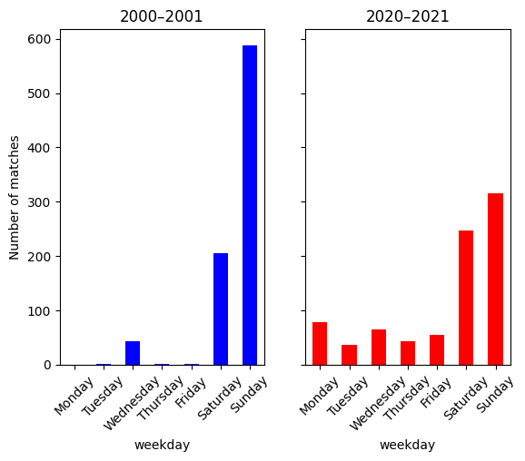

```python
fig, axes = plot.subplots(1, 2, sharey=True)

weekday_counts_2000.plot(kind='bar', ax=axes[0], color='blue')
axes[0].set_title('2000–2001')
axes[0].set_ylabel('Number of matches')
axes[0].tick_params(axis='x', rotation=45)

weekday_counts_2020.plot(kind='bar', ax=axes[1], color='red')
axes[1].set_title('2020–2021')
axes[1].tick_params(axis='x', rotation=45)

plot.show()
```

Now, we can see that the distribution of matches has changed during the week in recent years. We cannot appreciate this in the previous charts, since this difference has happened recently and most of the data is distributed as in the chart 2000-2001.

```python
hours_2000 = df1_2000['hour'].dropna()
hours_2020 = df1_2020['hour'].dropna()
```

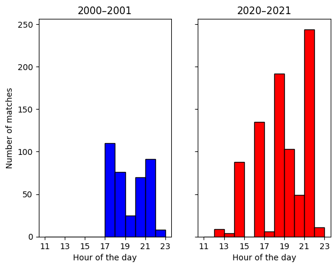

```python
fig, axes = plot.subplots(1, 2, sharey=True)

axes[0].hist(hours_2000, bins=range(11,24), edgecolor='black', color='blue')
axes[0].set_title('2000–2001')
axes[0].set_xlabel('Hour of the day')
axes[0].set_ylabel('Number of matches')
axes[0].set_xticks(range(11,24,2))

axes[1].hist(hours_2020, bins=range(11,24), edgecolor='black', color='red')
axes[1].set_title('2020–2021')
axes[1].set_xlabel('Hour of the day')
axes[1].set_xticks(range(11,24,2))

plot.show()
```

Again, this is a clear indicator of the change of tendency of the kickoff hours of the matches, which we could not see in the first charts as we explained before.

# Exercise 4

```python
df4 = first_division.copy()
```

```python
df4_season = df4[(df4['season'] == '2020-2021')].copy()
```

```python
teams_sorted = sorted(set(df4_season['home_team']).union(df4_season['away_team']))
```

The objective is to get a table as similar as possible to that from Wikipedia. Hence, it is not hardcoded given the aim of the exercice :)

```python
team_abbr = {
    'Alavés': 'ALA',
    'Athletic': 'ATH',
    'Atlético Madrid': 'ATL',
    'Barcelona': 'BAR',
    'Real Betis': 'BET',
    'Cádiz CF': 'CAD',
    'Celta de Vigo': 'CEL',
    'Elche CF': 'ELC',
    'Getafe': 'GET',
    'Granada CF': 'GRA',
    'SD Huesca': 'HUE',
    'Levante': 'LEV',
    'Real Madrid': 'RMA',
    'CA Osasuna': 'OSA',
    'Real Sociedad': 'RSO',
    'Real Valladolid': 'RVA',
    'SD Eibar': 'EIB',
    'Sevilla FC': 'SEV',
    'Valencia': 'VAL',
    'Villarreal': 'VIL'
}
```

```python
team_abbr_list = list(team_abbr.values())
teams_sorted = list(team_abbr.keys())
```

```python
df4_season['away_abbr'] = df4_season['away_team'].map(team_abbr)
```

```python
df4_season['resultado'] = df4_season['home_goals'].astype(str) + '-' + df4_season['away_goals'].astype(str)
```

```python
table4 = ( df4_season.pivot_table(index='home_team', columns='away_abbr', values='resultado',aggfunc='first', fill_value='—')
            .reindex(index=teams_sorted, columns=team_abbr_list, fill_value=0)
            .rename_axis(index=None, columns="Local \\ Visitante"))
```

Coloring the table

```python
def color_result(val):
    if isinstance(val, str):
        if val == '—':
            return 'background-color: #f6f6f6;'
        elif '-' in val:
            goles = val.split('-')
            if len(goles) == 2 and goles[0].isdigit() and goles[1].isdigit():
                g1, g2 = map(int, goles)
                if g1 > g2:
                    return 'background-color: #c7f7c4;'
                elif g1 < g2:
                    return 'background-color: #f7c4c4;'
                else:
                    return 'background-color: #f7f3c4;'
    return ''
```

```python
table4_a = (table4.style
    .map(color_result)
    .set_table_styles([
        {'selector': 'table',
         'props': [('border-collapse', 'collapse'),
                   ('border', '2px solid #000')]},
        {'selector': 'th, td',
         'props': [('border', '1px solid #000 !important'),
                   ('padding', '6px'),
                   ('text-align', 'center')]},
        {'selector': 'th', 'props': [
            ('background-color', '#f6f6f6'),
            ('color', '#2e2a8c'),
            ('border','1px solid #000 !important'),
            ('padding','6px'),
            ('text-align','center')
        ]},
        {'selector': 'thead tr:first-child th:first-child', 'props': [
            ('background-color', '#f6f6f6'),
            ('color', 'black'),
            ('text-transform', 'none'),
            ('font-weight', 'bold')
        ]}
    ])
)
```

```python
table4_a
```

| Local \ Visitante | ALA | ATH | ATL | BAR | BET | CAD | CEL | ELC | GET | GRA | HUE | LEV | RMA | OSA | RSO | RVA | EIB | SEV | VAL | VIL |
| --- | --- | --- | --- | --- | --- | --- | --- | --- | --- | --- | --- | --- | --- | --- | --- | --- | --- | --- | --- | --- |
| Alavés | — | 1-0 | 1-2 | 1-1 | 0-1 | 1-1 | 1-3 | 0-2 | 0-0 | 4-2 | 1-0 | 2-2 | 1-4 | 0-1 | 0-0 | 1-0 | 2-1 | 1-2 | 2-2 | 2-1 |
| Athletic | 0-0 | — | 2-1 | 2-3 | 4-0 | 0-1 | 0-2 | 1-0 | 5-1 | 2-1 | 2-0 | 2-0 | 0-1 | 2-2 | 0-1 | 2-2 | 1-1 | 2-1 | 1-1 | 1-1 |
| Atlético Madrid | 1-0 | 2-1 | — | 1-0 | 2-0 | 4-0 | 2-2 | 3-1 | 1-0 | 6-1 | 2-0 | 0-2 | 1-1 | 2-1 | 2-1 | 2-0 | 5-0 | 2-0 | 3-1 | 0-0 |
| Barcelona | 5-1 | 2-1 | 0-0 | — | 5-2 | 1-1 | 1-2 | 3-0 | 5-2 | 1-2 | 4-1 | 1-0 | 1-3 | 4-0 | 2-1 | 1-0 | 1-1 | 1-1 | 2-2 | 4-0 |
| Real Betis | 3-2 | 0-0 | 1-1 | 2-3 | — | 1-0 | 2-1 | 3-1 | 1-0 | 2-1 | 1-0 | 2-0 | 2-3 | 1-0 | 0-3 | 2-0 | 0-2 | 1-1 | 2-2 | 1-1 |
| Cádiz CF | 3-1 | 0-4 | 2-4 | 2-1 | 0-1 | — | 0-0 | 1-3 | 0-2 | 1-1 | 2-1 | 2-2 | 0-3 | 0-2 | 0-1 | 0-0 | 1-0 | 1-3 | 2-1 | 0-0 |
| Celta de Vigo | 2-0 | 0-0 | 0-2 | 0-3 | 2-3 | 4-0 | — | 3-1 | 1-0 | 3-1 | 2-1 | 2-0 | 1-3 | 2-1 | 1-4 | 1-1 | 1-1 | 3-4 | 2-1 | 0-4 |
| Elche CF | 0-2 | 2-0 | 0-1 | 0-2 | 1-1 | 1-1 | 1-1 | — | 1-3 | 0-1 | 0-0 | 1-0 | 1-1 | 2-2 | 0-3 | 1-1 | 1-0 | 2-1 | 2-1 | 2-2 |
| Getafe | 0-0 | 1-1 | 0-0 | 1-0 | 3-0 | 0-1 | 1-1 | 1-1 | — | 0-1 | 1-0 | 2-1 | 0-0 | 1-0 | 0-1 | 0-1 | 0-1 | 0-1 | 3-0 | 1-3 |
| Granada CF | 2-1 | 2-0 | 1-2 | 0-4 | 2-0 | 0-1 | 0-0 | 2-1 | 0-0 | — | 3-3 | 1-1 | 1-4 | 2-0 | 1-0 | 1-3 | 4-1 | 1-0 | 2-1 | 0-3 |
| SD Huesca | 1-0 | 1-0 | 0-0 | 0-1 | 0-2 | 0-2 | 3-4 | 3-1 | 0-2 | 3-2 | — | 1-1 | 1-2 | 0-0 | 1-0 | 2-2 | 1-1 | 0-1 | 0-0 | 0-0 |
| Levante | 1-1 | 1-1 | 1-1 | 3-3 | 4-3 | 2-2 | 1-1 | 1-1 | 3-0 | 2-2 | 0-2 | — | 0-2 | 0-1 | 2-1 | 2-2 | 2-1 | 0-1 | 1-0 | 1-5 |
| Real Madrid | 1-2 | 3-1 | 2-0 | 2-1 | 0-0 | 0-1 | 2-0 | 2-1 | 2-0 | 2-0 | 4-1 | 1-2 | — | 2-0 | 1-1 | 1-0 | 2-0 | 2-2 | 2-0 | 2-1 |
| CA Osasuna | 1-1 | 1-0 | 1-3 | 0-2 | 0-2 | 3-2 | 2-0 | 2-0 | 0-0 | 3-1 | 1-1 | 1-3 | 0-0 | — | 0-1 | 0-0 | 2-1 | 0-2 | 3-1 | 1-3 |
| Real Sociedad | 4-0 | 1-1 | 0-2 | 1-6 | 2-2 | 4-1 | 2-1 | 2-0 | 3-0 | 2-0 | 4-1 | 1-0 | 0-0 | 1-1 | — | 4-1 | 1-1 | 1-2 | 0-1 | 1-1 |
| Real Valladolid | 0-2 | 2-1 | 1-2 | 0-3 | 1-1 | 1-1 | 1-1 | 2-2 | 2-1 | 1-2 | 1-3 | 1-1 | 0-1 | 3-2 | 1-1 | — | 1-2 | 1-1 | 0-1 | 0-2 |
| SD Eibar | 3-0 | 1-2 | 1-2 | 0-1 | 1-1 | 0-2 | 0-0 | 0-1 | 0-0 | 2-0 | 1-1 | 0-1 | 1-3 | 0-0 | 0-1 | 1-1 | — | 0-2 | 0-0 | 1-3 |
| Sevilla FC | 1-0 | 0-1 | 1-0 | 0-2 | 1-0 | 3-0 | 4-2 | 2-0 | 3-0 | 2-1 | 1-0 | 1-0 | 0-1 | 1-0 | 3-2 | 1-1 | 0-1 | — | 1-0 | 2-0 |
| Valencia | 1-1 | 2-2 | 0-1 | 2-3 | 0-2 | 1-1 | 2-0 | 1-0 | 2-2 | 2-1 | 1-1 | 4-2 | 4-1 | 1-1 | 2-2 | 3-0 | 4-1 | 0-1 | — | 2-1 |
| Villarreal | 3-1 | 1-1 | 0-2 | 1-2 | 1-2 | 2-1 | 2-4 | 0-0 | 1-0 | 2-2 | 1-1 | 2-1 | 1-1 | 1-2 | 1-1 | 2-0 | 2-1 | 4-0 | 2-1 | — |

Using a gradient of colors is the easiest option. First we extract the match difference for each cell.

```python
def goal_diff(cell):
    if not isinstance(cell, str) or '-' not in cell:
        return np.nan
    a, b = cell.split('-')
    if a.isdigit() and b.isdigit():
        return int(a) - int(b)
    return np.nan
```

```python
gdiff = table4.map(goal_diff)
```

```python
max_abs = np.nanmax(np.abs(gdiff.values)) or 1
vmin, vmax = -max_abs, max_abs
```

```python
table4_b = (
    table4.style
    .background_gradient(cmap='RdYlGn', gmap=gdiff, vmin=vmin, vmax=vmax, axis = None)
    .map(lambda v: 'background-color:#f6f6f6; color:#000;' if v == '—' else '')
    .set_table_styles([
        {'selector': 'table', 'props': [('border-collapse','collapse'),
                                        ('border','2px solid #000')]},
        {'selector': 'th, td','props': [('border','1px solid #000 !important'),
                                        ('padding','6px'),
                                        ('text-align','center')]},
        {'selector': 'th', 'props': [
            ('background-color', '#f6f6f6'),
            ('color', '#2e2a8c'),
            ('border','1px solid #000 !important'),
            ('padding','6px'),
            ('text-align','center')
        ]},
        {'selector': 'thead tr:first-child th:first-child', 'props': [
            ('background-color', '#f6f6f6'),
            ('color', 'black'),
            ('text-transform', 'none'),
            ('font-weight', 'bold')
        ]}
    ])
)
```

```python
table4_b
```

| Local \ Visitante | ALA | ATH | ATL | BAR | BET | CAD | CEL | ELC | GET | GRA | HUE | LEV | RMA | OSA | RSO | RVA | EIB | SEV | VAL | VIL |
| --- | --- | --- | --- | --- | --- | --- | --- | --- | --- | --- | --- | --- | --- | --- | --- | --- | --- | --- | --- | --- |
| Alavés | — | 1-0 | 1-2 | 1-1 | 0-1 | 1-1 | 1-3 | 0-2 | 0-0 | 4-2 | 1-0 | 2-2 | 1-4 | 0-1 | 0-0 | 1-0 | 2-1 | 1-2 | 2-2 | 2-1 |
| Athletic | 0-0 | — | 2-1 | 2-3 | 4-0 | 0-1 | 0-2 | 1-0 | 5-1 | 2-1 | 2-0 | 2-0 | 0-1 | 2-2 | 0-1 | 2-2 | 1-1 | 2-1 | 1-1 | 1-1 |
| Atlético Madrid | 1-0 | 2-1 | — | 1-0 | 2-0 | 4-0 | 2-2 | 3-1 | 1-0 | 6-1 | 2-0 | 0-2 | 1-1 | 2-1 | 2-1 | 2-0 | 5-0 | 2-0 | 3-1 | 0-0 |
| Barcelona | 5-1 | 2-1 | 0-0 | — | 5-2 | 1-1 | 1-2 | 3-0 | 5-2 | 1-2 | 4-1 | 1-0 | 1-3 | 4-0 | 2-1 | 1-0 | 1-1 | 1-1 | 2-2 | 4-0 |
| Real Betis | 3-2 | 0-0 | 1-1 | 2-3 | — | 1-0 | 2-1 | 3-1 | 1-0 | 2-1 | 1-0 | 2-0 | 2-3 | 1-0 | 0-3 | 2-0 | 0-2 | 1-1 | 2-2 | 1-1 |
| Cádiz CF | 3-1 | 0-4 | 2-4 | 2-1 | 0-1 | — | 0-0 | 1-3 | 0-2 | 1-1 | 2-1 | 2-2 | 0-3 | 0-2 | 0-1 | 0-0 | 1-0 | 1-3 | 2-1 | 0-0 |
| Celta de Vigo | 2-0 | 0-0 | 0-2 | 0-3 | 2-3 | 4-0 | — | 3-1 | 1-0 | 3-1 | 2-1 | 2-0 | 1-3 | 2-1 | 1-4 | 1-1 | 1-1 | 3-4 | 2-1 | 0-4 |
| Elche CF | 0-2 | 2-0 | 0-1 | 0-2 | 1-1 | 1-1 | 1-1 | — | 1-3 | 0-1 | 0-0 | 1-0 | 1-1 | 2-2 | 0-3 | 1-1 | 1-0 | 2-1 | 2-1 | 2-2 |
| Getafe | 0-0 | 1-1 | 0-0 | 1-0 | 3-0 | 0-1 | 1-1 | 1-1 | — | 0-1 | 1-0 | 2-1 | 0-0 | 1-0 | 0-1 | 0-1 | 0-1 | 0-1 | 3-0 | 1-3 |
| Granada CF | 2-1 | 2-0 | 1-2 | 0-4 | 2-0 | 0-1 | 0-0 | 2-1 | 0-0 | — | 3-3 | 1-1 | 1-4 | 2-0 | 1-0 | 1-3 | 4-1 | 1-0 | 2-1 | 0-3 |
| SD Huesca | 1-0 | 1-0 | 0-0 | 0-1 | 0-2 | 0-2 | 3-4 | 3-1 | 0-2 | 3-2 | — | 1-1 | 1-2 | 0-0 | 1-0 | 2-2 | 1-1 | 0-1 | 0-0 | 0-0 |
| Levante | 1-1 | 1-1 | 1-1 | 3-3 | 4-3 | 2-2 | 1-1 | 1-1 | 3-0 | 2-2 | 0-2 | — | 0-2 | 0-1 | 2-1 | 2-2 | 2-1 | 0-1 | 1-0 | 1-5 |
| Real Madrid | 1-2 | 3-1 | 2-0 | 2-1 | 0-0 | 0-1 | 2-0 | 2-1 | 2-0 | 2-0 | 4-1 | 1-2 | — | 2-0 | 1-1 | 1-0 | 2-0 | 2-2 | 2-0 | 2-1 |
| CA Osasuna | 1-1 | 1-0 | 1-3 | 0-2 | 0-2 | 3-2 | 2-0 | 2-0 | 0-0 | 3-1 | 1-1 | 1-3 | 0-0 | — | 0-1 | 0-0 | 2-1 | 0-2 | 3-1 | 1-3 |
| Real Sociedad | 4-0 | 1-1 | 0-2 | 1-6 | 2-2 | 4-1 | 2-1 | 2-0 | 3-0 | 2-0 | 4-1 | 1-0 | 0-0 | 1-1 | — | 4-1 | 1-1 | 1-2 | 0-1 | 1-1 |
| Real Valladolid | 0-2 | 2-1 | 1-2 | 0-3 | 1-1 | 1-1 | 1-1 | 2-2 | 2-1 | 1-2 | 1-3 | 1-1 | 0-1 | 3-2 | 1-1 | — | 1-2 | 1-1 | 0-1 | 0-2 |
| SD Eibar | 3-0 | 1-2 | 1-2 | 0-1 | 1-1 | 0-2 | 0-0 | 0-1 | 0-0 | 2-0 | 1-1 | 0-1 | 1-3 | 0-0 | 0-1 | 1-1 | — | 0-2 | 0-0 | 1-3 |
| Sevilla FC | 1-0 | 0-1 | 1-0 | 0-2 | 1-0 | 3-0 | 4-2 | 2-0 | 3-0 | 2-1 | 1-0 | 1-0 | 0-1 | 1-0 | 3-2 | 1-1 | 0-1 | — | 1-0 | 2-0 |
| Valencia | 1-1 | 2-2 | 0-1 | 2-3 | 0-2 | 1-1 | 2-0 | 1-0 | 2-2 | 2-1 | 1-1 | 4-2 | 4-1 | 1-1 | 2-2 | 3-0 | 4-1 | 0-1 | — | 2-1 |
| Villarreal | 3-1 | 1-1 | 0-2 | 1-2 | 1-2 | 2-1 | 2-4 | 0-0 | 1-0 | 2-2 | 1-1 | 2-1 | 1-1 | 1-2 | 1-1 | 2-0 | 2-1 | 4-0 | 2-1 | — |

# Exercise 5

```python
df5 = first_division[((first_division['home_team'] == 'Barcelona') & (df4['away_team'] == 'Real Madrid')) | ((first_division['home_team'] == 'Barcelona') & (first_division['away_team'] == 'Barcelona'))].copy()
# Barcelona and Real Madrid have never been in any other division (nor have Atletico de Madrid). We can work with the data from first_division without problems.
```

```python
df5
```

|  | season | division | matchday | date | time | home_team | away_team | score | home_goals | away_goals | result | goal_difference |
| --- | --- | --- | --- | --- | --- | --- | --- | --- | --- | --- | --- | --- |
| 5 | 1928-1929 | 1 | 2 | 2/17/29 | None | Barcelona | Real Madrid | 1:2 | 1 | 2 | 2 | 1 |
| 131 | 1929-1930 | 1 | 9 | 1/26/30 | None | Barcelona | Real Madrid | 1:4 | 1 | 4 | 2 | 3 |
| 266 | 1930-1931 | 1 | 18 | 4/5/31 | None | Barcelona | Real Madrid | 3:1 | 3 | 1 | 1 | 2 |
| 356 | 1931-1932 | 1 | 18 | 4/3/32 | None | Barcelona | Real Madrid | 2:2 | 2 | 2 | X | 0 |
| 385 | 1932-1933 | 1 | 6 | 1/1/33 | None | Barcelona | Real Madrid | 1:1 | 1 | 1 | X | 0 |
| ... | ... | ... | ... | ... | ... | ... | ... | ... | ... | ... | ... | ... |
| 24049 | 2016-2017 | 1 | 14 | 12/3/16 | 4:15 PM | Barcelona | Real Madrid | 1:1 | 1 | 1 | X | 0 |
| 24656 | 2017-2018 | 1 | 36 | 5/6/18 | 8:45 PM | Barcelona | Real Madrid | 2:2 | 2 | 2 | X | 0 |
| 24775 | 2018-2019 | 1 | 10 | 10/28/18 | 4:15 PM | Barcelona | Real Madrid | 5:1 | 5 | 1 | 1 | 4 |
| 25157 | 2019-2020 | 1 | 10 | 12/18/19 | 8:00 PM | Barcelona | Real Madrid | 0:0 | 0 | 0 | X | 0 |
| 25499 | 2020-2021 | 1 | 7 | 10/24/20 | 4:00 PM | Barcelona | Real Madrid | 1:3 | 1 | 3 | 2 | 2 |

91 rows × 12 columns

```python
def winner_from_row(row):
    if row['result'] == '1':
        return row['home_team']
    elif row['result'] == '2':
        return row['away_team']
    else:
        return 'Tie'
```

```python
df5['who_won'] = df5.apply(winner_from_row, axis=1)
```

```python
win_counts = df5['who_won'].value_counts().reindex(['Barcelona', 'Tie', 'Real Madrid']).fillna(0).astype(int)
win_counts
```

```
who_won
Barcelona      50
Tie            20
Real Madrid    21
Name: count, dtype: int64
```

```python
goals_barca = (df5.loc[df5['home_team'] == 'Barcelona', 'home_goals'].sum() + df5.loc[df5['away_team'] == 'Barcelona', 'away_goals'].sum())
goals_barca
```

```
np.int64(179)
```

```python
goals_madrid = (df5.loc[df5['home_team'] == 'Real Madrid', 'home_goals'].sum() + df5.loc[df5['away_team'] == 'Real Madrid', 'away_goals'].sum())
goals_madrid
```

```
np.int64(108)
```

```python
goal_counts = [int(goals_barca), int(goals_madrid)]
goal_labels = ['Barcelona', 'Real Madrid']
```

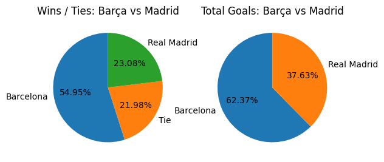

```python
fig, axes = plot.subplots(1, 2, sharey=True)

axes[0].pie(win_counts.values, labels=win_counts.index, autopct='%1.2f%%', startangle=90)
axes[0].set_title('Wins / Ties: Barça vs Madrid')

axes[1].pie(goal_counts, labels=goal_labels, autopct='%1.2f%%', startangle=90)
axes[1].set_title('Total Goals: Barça vs Madrid')

plot.show()
```

Now, let's creat a function that does all this.

```python
def plot_direct_confrontations_stats(team1, team2, df, season=None):

    sub = df[((df['home_team'] == team1) & (df['away_team'] == team2)) | ((df['home_team'] == team2) & (df['away_team'] == team1))].copy()

    if season is not None:
        sub = sub[sub['season'] == season].copy()

    if sub.empty:
        print("No matches found between those teams with the current filters.")
        return None

    sub['who_won'] = np.where(sub['result'] == '1', sub['home_team'], np.where(sub['result'] == '2', sub['away_team'], 'Tie'))

    win_counts = sub['who_won'].value_counts().reindex([team1, 'Tie', team2]).fillna(0).astype(int)

    goals_team1 = (sub.loc[sub['home_team'] == team1, 'home_goals'].sum() + sub.loc[sub['away_team'] == team1, 'away_goals'].sum())

    goals_team2 = (sub.loc[sub['home_team'] == team2, 'home_goals'].sum() + sub.loc[sub['away_team'] == team2, 'away_goals'].sum())

    fig, axes = plot.subplots(1, 2, figsize=(10, 4))

    axes[0].pie(win_counts.values, labels=win_counts.index, autopct='%1.2f%%', startangle=90)
    axes[0].set_title(f'Wins / Ties: {team1} vs {team2}')

    axes[1].pie([int(goals_team1), int(goals_team2)], labels=[team1, team2], autopct='%1.2f%%', startangle=90)
    axes[1].set_title(f'Total Goals: {team1} vs {team2}')

    plot.tight_layout()
    plot.show()
```

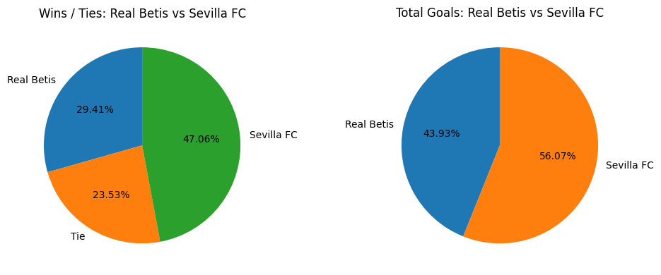

```python
plot_direct_confrontations_stats('Real Betis', 'Sevilla FC', valid_matches, None)
```

# Exercise 6

```python
valid_matches['date_dt'] = pd.to_datetime(valid_matches['date'], errors='coerce')
mask = valid_matches['date_dt'].isna()
valid_matches.loc[mask, 'date_dt'] = pd.to_datetime(valid_matches.loc[mask, 'date'], dayfirst=True, errors='coerce')
```

```python
def team_matches(df, team):
    team_df = df[(df['home_team'] == team) | (df['away_team'] == team)].copy()
    team_df = team_df.sort_values('date_dt')

    def is_undefeated(row):
        if row['result'] == 'X':
            return True
        if row['result'] == '1' and row['home_team'] == team:
            return True
        if row['result'] == '2' and row['away_team'] == team:
            return True
        return False

    team_df['undefeated'] = team_df.apply(is_undefeated, axis=1)
    return team_df
```

```python
def longest_streak(df, team):
    team_df = team_matches(df, team)
    team_df = team_df.sort_values('date_dt').reset_index(drop=True)

    longest = 0
    current = 0
    best_start = None
    best_end = None

    for i in range(len(team_df)):
        if team_df.loc[i, 'undefeated']:
            current += 1
            if current == 1:
                start = team_df.loc[i, 'date_dt']
            if current > longest:
                longest = current
                best_start = start
                best_end = team_df.loc[i, 'date_dt']
        else:
            current = 0

    if pd.notna(best_start):
        start_str = best_start.strftime('%d/%m/%Y')
    else:
        start_str = None

    if pd.notna(best_end):
        end_str = best_end.strftime('%d/%m/%Y')
    else:
        end_str = None

    return longest, start_str, end_str
```

```python
longest_streak(valid_matches, 'Real Sociedad')
```

```
(38, '29/04/1979', '04/05/1980')
```

```python
teams = sorted(set(valid_matches['home_team']).union(valid_matches['away_team']))
```

```python
streaks_df = []
for t in teams:
    length, start, end = longest_streak(valid_matches, t)
    streaks_df.append({'team': t, 'streak': int(length), 'start': start, 'end': end})
streaks_df = pd.DataFrame(streaks_df)
```

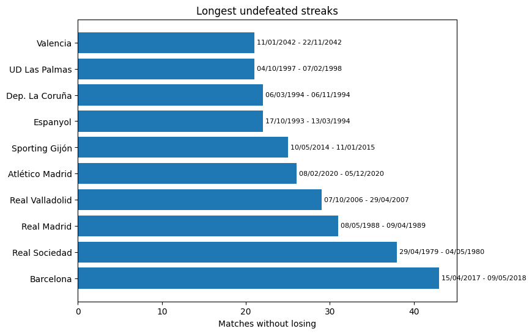

```python
top10 = streaks_df.sort_values('streak', ascending=False).head(10)

plot.figure(figsize=(8, 6))
plot.barh(top10['team'], top10['streak'])

plot.xlabel('Matches without losing')
plot.title('Longest undefeated streaks')

for i, row in enumerate(top10.itertuples()):
    plot.text(row.streak + 0.3, i, f"{row.start} - {row.end}", va='center', fontsize=8)

plot.show()
```

# Exercise 7

```python
df7 = valid_matches.copy()
```

```python
df7['result'] = df7['result'].astype(str)
```

```python
home = df7[['season','division','home_team','home_goals','away_goals','result']].copy()
```

```python
home = home.rename(columns={'home_team':'team', 'home_goals':'GF', 'away_goals':'GA'})
home['W'] = (home['result'] == '1').astype(int)
home['L'] = (home['result'] == '2').astype(int)
home['T'] = (home['result'] == 'X').astype(int)
home['Pts'] = home['W']*3 + home['T']*1
```

```python
# We don't need the result column anymore, we already have the information in 'W','T','L'.
cols = ['season','division','team','GF','GA','W','L','T','Pts']
home = home[cols]
```

```python
away = df7[['season','division','away_team','home_goals','away_goals','result']].copy()
```

```python
away = away.rename(columns={'away_team':'team', 'away_goals':'GF', 'home_goals':'GA'})
away['W'] = (away['result'] == '2').astype(int)
away['L'] = (away['result'] == '1').astype(int)
away['T'] = (away['result'] == 'X').astype(int)
away['Pts'] = away['W']*3 + away['T']*1
```

```python
away = away[cols]
```

```python
long = pd.concat([home, away], ignore_index=True)
long
```

|  | season | division | team | GF | GA | W | L | T | Pts |
| --- | --- | --- | --- | --- | --- | --- | --- | --- | --- |
| 0 | 1928-1929 | 1 | Arenas Club | 2 | 3 | 0 | 1 | 0 | 0 |
| 1 | 1928-1929 | 1 | Espanyol | 3 | 2 | 1 | 0 | 0 | 3 |
| 2 | 1928-1929 | 1 | Real Madrid | 5 | 0 | 1 | 0 | 0 | 3 |
| 3 | 1928-1929 | 1 | Donostia | 1 | 1 | 0 | 0 | 1 | 1 |
| 4 | 1928-1929 | 1 | Racing | 0 | 2 | 0 | 1 | 0 | 0 |
| ... | ... | ... | ... | ... | ... | ... | ... | ... | ... |
| 95995 | 2021-2022 | 2 | Girona | 1 | 2 | 0 | 1 | 0 | 0 |
| 95996 | 2021-2022 | 2 | UD Almería | 1 | 2 | 0 | 1 | 0 | 0 |
| 95997 | 2021-2022 | 2 | Real Valladolid | 2 | 0 | 1 | 0 | 0 | 3 |
| 95998 | 2021-2022 | 2 | CF Fuenlabrada | 0 | 0 | 0 | 0 | 1 | 1 |
| 95999 | 2021-2022 | 2 | SD Eibar | 1 | 0 | 1 | 0 | 0 | 3 |

96000 rows × 9 columns

```python
standings = (long.groupby(['season','division','team'], as_index=False).agg(GF=('GF','sum'), GA=('GA','sum'), W =('W','sum'), L =('L','sum'), T =('T','sum'), Pts=('Pts','sum')))
```

```python
standings['GD'] = standings['GF'] - standings['GA']
standings
```

|  | season | division | team | GF | GA | W | L | T | Pts | GD |
| --- | --- | --- | --- | --- | --- | --- | --- | --- | --- | --- |
| 0 | 1928-1929 | 1 | Arenas Club | 32 | 39 | 8 | 7 | 3 | 27 | -7 |
| 1 | 1928-1929 | 1 | Athletic | 43 | 33 | 8 | 6 | 4 | 28 | 10 |
| 2 | 1928-1929 | 1 | Athletic Madrid | 43 | 41 | 8 | 8 | 2 | 26 | 2 |
| 3 | 1928-1929 | 1 | Barcelona | 37 | 23 | 11 | 4 | 3 | 36 | 14 |
| 4 | 1928-1929 | 1 | Catalunya | 45 | 49 | 6 | 8 | 4 | 22 | -4 |
| ... | ... | ... | ... | ... | ... | ... | ... | ... | ... | ... |
| 2781 | 2021-2022 | 2 | SD Huesca | 5 | 2 | 2 | 1 | 0 | 6 | 3 |
| 2782 | 2021-2022 | 2 | Sporting Gijón | 3 | 1 | 2 | 0 | 1 | 7 | 2 |
| 2783 | 2021-2022 | 2 | UD Almería | 6 | 4 | 2 | 1 | 0 | 6 | 2 |
| 2784 | 2021-2022 | 2 | UD Ibiza | 4 | 3 | 1 | 0 | 2 | 5 | 1 |
| 2785 | 2021-2022 | 2 | UD Las Palmas | 3 | 2 | 1 | 0 | 2 | 5 | 1 |

2786 rows × 10 columns

```python
num_cols = ['GF','GA','W','L','T','Pts','GD']
standings[num_cols] = standings[num_cols].astype(int)
```

```python
standings = standings.sort_values(['season','division','Pts','GD','GF'], ascending=[False, True, False, False, False])
```

```python
standings['rank'] = standings.groupby(['season','division'], sort=False).cumcount() + 1
```

```python
standings
```

|  | season | division | team | GF | GA | W | L | T | Pts | GD | rank |
| --- | --- | --- | --- | --- | --- | --- | --- | --- | --- | --- | --- |
| 2759 | 2021-2022 | 1 | Real Madrid | 8 | 4 | 2 | 0 | 1 | 7 | 4 | 1 |
| 2761 | 2021-2022 | 1 | Sevilla FC | 5 | 1 | 2 | 0 | 1 | 7 | 4 | 2 |
| 2762 | 2021-2022 | 1 | Valencia | 5 | 1 | 2 | 0 | 1 | 7 | 4 | 3 |
| 2747 | 2021-2022 | 1 | Barcelona | 7 | 4 | 2 | 0 | 1 | 7 | 3 | 4 |
| 2746 | 2021-2022 | 1 | Atlético Madrid | 5 | 3 | 2 | 0 | 1 | 7 | 2 | 5 |
| ... | ... | ... | ... | ... | ... | ... | ... | ... | ... | ... | ... |
| 2 | 1928-1929 | 1 | Athletic Madrid | 43 | 41 | 8 | 8 | 2 | 26 | 2 | 6 |
| 6 | 1928-1929 | 1 | Espanyol | 32 | 38 | 7 | 7 | 4 | 25 | -6 | 7 |
| 4 | 1928-1929 | 1 | Catalunya | 45 | 49 | 6 | 8 | 4 | 22 | -4 | 8 |
| 9 | 1928-1929 | 1 | Real Unión | 40 | 42 | 5 | 11 | 2 | 17 | -2 | 9 |
| 7 | 1928-1929 | 1 | Racing | 25 | 50 | 3 | 12 | 3 | 12 | -25 | 10 |

2786 rows × 11 columns

The only thing left is to expord it to .xlsx

```python
dir = Path.cwd().parent

reports_dir = dir / 'reports'
os.makedirs(reports_dir, exist_ok=True)
out_path = reports_dir / 'SeasonStandings.xlsx'
standings.to_excel(out_path, index=False)
print("Saved:", out_path)
```

```
Saved: /mnt/c/Users/laura/Desktop/master/RI/python/la-quiniela/reports/SeasonStandings.xlsx
```

# Exercise 8

```python
standings_div1 = standings.loc[standings['division'] == 1]
num_teams_div1 = standings_div1.groupby('season')["rank"].count()
num_teams_div1
```

```
season
1928-1929    10
1929-1930    10
1930-1931    10
1931-1932    10
1932-1933    10
             ..
2017-2018    20
2018-2019    20
2019-2020    20
2020-2021    20
2021-2022    20
Name: rank, Length: 91, dtype: int64
```

```python
def get_abs_rank(row):
    if row['division'] == 1:
        return row['rank']
    else:
        return row['rank'] + num_teams_div1[row['season']]
```

```python
standings['abs_rank'] = standings.apply(get_abs_rank, axis=1)
```

```python
villarreal_stats = standings.loc[standings['team'] == 'Villarreal'].sort_values(by='season', ascending=True)
```

```python
def shorten_season_date(long_date):
    years = long_date.split('-')
    return years[0][2:4] + '-' + years[1][2:4]
```

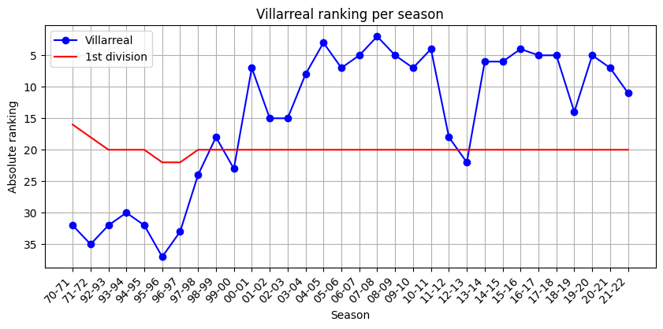

```python
short_season_dates = villarreal_stats['season'].apply(shorten_season_date)
num_teams_div1_villarreal = num_teams_div1.loc[villarreal_stats['season']].to_numpy()

plot.figure(figsize=(10,4))

plot.plot(short_season_dates, villarreal_stats['abs_rank'], label='Villarreal', color='blue', marker='o', linestyle='-')
plot.plot(short_season_dates, num_teams_div1_villarreal, label='1st division', color='red', marker='', linestyle='-')

plot.title("Villarreal ranking per season")
plot.xlabel("Season")
plot.ylabel("Absolute ranking")
plot.legend()
plot.grid(True)
plot.xticks(rotation=45, ha='right')
plot.gca().invert_yaxis()

plot.show()
```

```python
def ranking_evolution(*teams):
    season_dates = standings['season'].sort_values(ascending=True).drop_duplicates()
    mask = np.full(len(standings), False)
    for team in teams:
        mask = mask | (standings['team'] == team)
    stands = standings.loc[mask].sort_values(by='season', ascending=True)
    num_first_div_teams = num_teams_div1.loc[season_dates].to_numpy()
    season_dates = season_dates.apply(shorten_season_date)

    plot.figure(figsize=(11,4))
    plot.plot(season_dates, num_first_div_teams, label='1st division', color='red', marker='', linestyle='-')

    for team in teams:
        team_stats = stands.loc[stands['team'] == team]
        team_season_dates = team_stats['season'].apply(shorten_season_date)
        plot.plot(team_season_dates, team_stats['abs_rank'], label=team, marker='', linestyle='-')

    plot.title("Ranking per season")
    plot.xlabel("Season")
    plot.ylabel("Absolute ranking")
    plot.legend()
    plot.grid(True, which='both', axis='both', linestyle='--', alpha=0.5)

    xtick_list = season_dates.tolist()
    plot.xticks(xtick_list[::5], rotation=45, ha='right')

    plot.gca().invert_yaxis()

    return plot
```

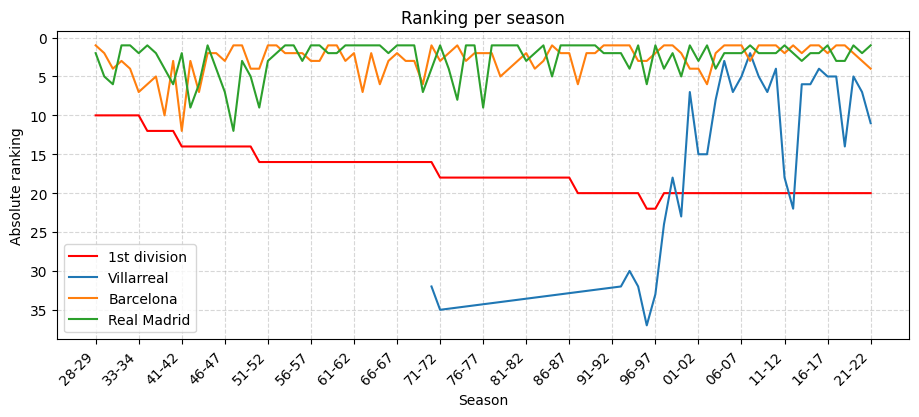

```python
ranking_evolution("Villarreal", "Barcelona", "Real Madrid").show()
```

# Exercise 9

```python
df9 = standings.copy()
```

```python
df9.sort_values(by=['team', 'season'], ascending=True, inplace=True)
```

```python
df9['div_change'] = (
    (df9.groupby('team')['division'].diff().fillna(0) != 0).astype(int)
)
```

```python
top5_elevator_teams =  df9.groupby('team')['div_change'].sum().sort_values(ascending=False).head(5)
top5_elevator_teams
```

```
team
Dep. La Coruña    20
Celta de Vigo     17
Racing            17
Rayo Vallecano    15
Real Betis        14
Name: div_change, dtype: int64
```

As we can see, the top 5 'elevator' teams are Dep. La Coruña, Celta de Vigo, Racing, Rayo Vallecano and Real Betis. All of them have shifted divisions more than 13 times.

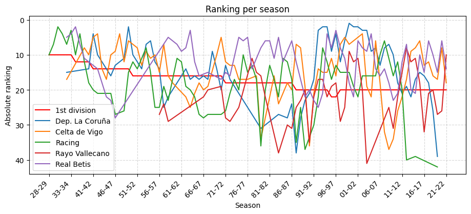

```python
top5_elevators_list = top5_elevator_teams.index.tolist()
ranking_evolution(*top5_elevators_list).show()
```

# Exercise 10

```python
df10 = valid_matches.copy()
df10['result'] = df10['result'].astype(str)
```

```python
home = df10[['season','division','matchday', 'home_team','home_goals','away_goals','result']].copy()

home = home.rename(columns={'home_team':'team', 'home_goals':'GF', 'away_goals':'GA'})
```

```python
home['res'] = home['result'].map({'1':'W','2':'L','X':'T'})
home['W']   = (home['res']=='W').astype(int)
home['L']   = (home['res']=='L').astype(int)
home['T']   = (home['res']=='T').astype(int)
home['Pts'] = home['W']*3 + home['T']
```

```python
cols = ['season','division','matchday','team','GF','GA','W','L','T','Pts','res']
home = home[cols]
```

```python
away = df10[['season','division','matchday', 'away_team','home_goals','away_goals','result']].copy()

away = away.rename(columns={'away_team':'team', 'away_goals':'GF', 'home_goals':'GA'})
```

```python
away['res'] = away['result'].map({'2':'W','1':'L','X':'T'})
away['W']   = (away['res']=='W').astype(int)
away['L']   = (away['res']=='L').astype(int)
away['T']   = (away['res']=='T').astype(int)
away['Pts'] = away['W']*3 + away['T']
```

```python
away = away[cols]
```

```python
long_md = pd.concat([home, away], ignore_index=True)
```

```python
long_md = long_md.sort_values(['season','division','team','matchday']).reset_index(drop=True)
```

```python
grp = long_md.groupby(['season','division','team'], sort=False)
```

```python
long_md['GF_cum']  = grp['GF'].cumsum()
long_md['GA_cum']  = grp['GA'].cumsum()
long_md['W_cum']   = grp['W'].cumsum()
long_md['L_cum']   = grp['L'].cumsum()
long_md['T_cum']   = grp['T'].cumsum()
long_md['Pts_cum'] = grp['Pts'].cumsum()
long_md['GD_cum']  = long_md['GF_cum'] - long_md['GA_cum']
```

```python
def compute_last5(s):
    vals = s.tolist()
    out = []
    for i in range(len(vals)):
        prev = vals[max(0, i-5): i]
        out.append(prev[::-1])
    return pd.Series(out, index=s.index)
```

```python
long_md['last_5'] = (long_md.groupby(['season','division','team'])['res'].apply(compute_last5).reset_index(level=[0,1,2], drop=True))
```

```python
matchday_table = long_md[['season','division','matchday','team', 'GF_cum','GA_cum','GD_cum','W_cum','L_cum','T_cum','Pts_cum','last_5']].copy()
```

```python
matchday_table = matchday_table.rename(columns={'GF_cum':'GF','GA_cum':'GA','GD_cum':'GD', 'W_cum':'W','L_cum':'L','T_cum':'T','Pts_cum':'Pts'})
```

```python
matchday_table = matchday_table.sort_values(['season','division','matchday','Pts','GD','GF'], ascending=[True, True, True, False, False, False])
```

```python
matchday_table['rank'] = (matchday_table.groupby(['season','division','matchday'], sort=False).cumcount() + 1)
```

```python
matchday_table = matchday_table[['season','division','matchday','rank','team','GF','GA','GD','W','L','T','Pts','last_5']]
matchday_table
```

|  | season | division | matchday | rank | team | GF | GA | GD | W | L | T | Pts | last_5 |
| --- | --- | --- | --- | --- | --- | --- | --- | --- | --- | --- | --- | --- | --- |
| 144 | 1928-1929 | 1 | 1 | 1 | Real Madrid | 5 | 0 | 5 | 1 | 0 | 0 | 3 | [] |
| 54 | 1928-1929 | 1 | 1 | 2 | Barcelona | 2 | 0 | 2 | 1 | 0 | 0 | 3 | [] |
| 36 | 1928-1929 | 1 | 1 | 3 | Athletic Madrid | 3 | 2 | 1 | 1 | 0 | 0 | 3 | [] |
| 108 | 1928-1929 | 1 | 1 | 4 | Espanyol | 3 | 2 | 1 | 1 | 0 | 0 | 3 | [] |
| 18 | 1928-1929 | 1 | 1 | 5 | Athletic | 1 | 1 | 0 | 0 | 0 | 1 | 1 | [] |
| ... | ... | ... | ... | ... | ... | ... | ... | ... | ... | ... | ... | ... | ... |
| 95970 | 2021-2022 | 2 | 3 | 16 | Real Oviedo | 3 | 4 | -1 | 0 | 1 | 2 | 2 | [L, T] |
| 95947 | 2021-2022 | 2 | 3 | 17 | CD Lugo | 2 | 4 | -2 | 0 | 1 | 2 | 2 | [T, T] |
| 95944 | 2021-2022 | 2 | 3 | 18 | CD Leganés | 1 | 3 | -2 | 0 | 2 | 1 | 1 | [T, L] |
| 95941 | 2021-2022 | 2 | 3 | 19 | Burgos CF | 0 | 2 | -2 | 0 | 2 | 1 | 1 | [T, L] |
| 95938 | 2021-2022 | 2 | 3 | 20 | Alcorcón | 0 | 4 | -4 | 0 | 3 | 0 | 0 | [L, L] |

96000 rows × 13 columns

```python
dir = Path.cwd().parent

reports_dir = dir / 'reports'
os.makedirs(reports_dir, exist_ok=True)
out_path = reports_dir / 'MatchdayStandings.xlsx'
standings.to_excel(out_path, index=False)
print("Saved:", out_path)
```

```
Saved: /mnt/c/Users/laura/Desktop/master/RI/python/la-quiniela/reports/MatchdayStandings.xlsx
```